# Non-normal covariates: heavy tails and skew

This note adds one factor to the paper grid of Sivula et al. (2025): the distribution of the covariates. In the paper the covariates are standard normal. Here they also have two other kinds of distribution:

- **Heavy tails:** standard t, with degrees of freedom from 30 down to 1 (Cauchy).
- **Skew:** skew-t(5) and gamma(2), standardised to mean 0 and variance 1. Their fourth moment is finite. So they show the effect of skew without infinite moments.

Everything else stays as in the paper: the gaussian family, the measure elpd, and the cells of Fig. 5 and Fig. 6.

Render it from the pipeline folder:

```bash
Rscript -e 'rmarkdown::render("notes/xdf_scenario.Rmd", output_dir = ".")'
```

# Data generating process

`make_data_gaussian()` in `workflow/scripts/lib/dgp.R` draws one data set of $n$ observations as

$$y_i = \beta_0 + \beta_1 x_{i1} + \beta_t x_{i2} + \varepsilon_i,
\qquad
\varepsilon_i \sim \mathrm{N}(\mu_i, \sigma^2),
\qquad
\beta = (0, 1, \beta_t), \quad \sigma^2 = 1.$$

## Models

`lib/glm.R` fits two normal linear regressions. Model A omits $x_{2}$. Model B includes it.

$$\begin{aligned}
\text{A:} \quad & y_i \sim \mathrm{N}(b_0 + b_1 x_{i1},\ \tau^2), \\
\text{B:} \quad & y_i \sim \mathrm{N}(b_0 + b_1 x_{i1} + b_2
x_{i2},\ \tau^2),
\end{aligned}
\qquad
p(b, \log\tau^2) \propto 1.$$

The noise variance $\tau^2$ is unknown. The models do not get the true $\sigma^2 = 1$. They estimate $\tau^2$ from the data. So the posterior predictive is a Student-t with $n - d$ degrees of freedom, where $d$ is the number of coefficients. The exact LOO predictive is a Student-t with $n - 1 - d$ degrees of freedom.

The quantity of interest is the elpd difference $\mathrm{elpd}_A - \mathrm{elpd}_B$.

## Covariates

The covariates $x_{ij}$ are independent. `x_dist` in the cell table sets their distribution: `normal`, `t<df>`, `skewt<df>` or `gamma<k>`.

### t

With $\nu$ degrees of freedom the covariates are

$$x_{ij} = \frac{z_{ij}}{\sqrt{w_{ij} / \nu}},
\qquad
z_{ij} \sim \mathrm{N}(0, 1),
\qquad
w_{ij} = F^{-1}_{\chi^2_\nu}(u_{ij}),
\quad u_{ij} \sim \mathrm{U}(0, 1),$$

so $x_{ij} \sim t_\nu$. For $\nu = \infty$ the denominator is 1, and $x_{ij} = z_{ij}$ is the normal covariate of the paper.

- The t is not rescaled to unit variance. Its variance is $\nu / (\nu - 2)$, which is infinite for $\nu \le 2$.

### Skew-t

The Azzalini skew-t with $\nu$ degrees of freedom and slant $\alpha$ = 5 is

$$s_{ij} = \frac{\delta\,\lvert z^0_{ij}\rvert + \sqrt{1 - \delta^2}\,
z_{ij}}
{\sqrt{w_{ij} / \nu}},
\qquad
\delta = \frac{\alpha}{\sqrt{1 + \alpha^2}},
\qquad
z^0_{ij} \sim \mathrm{N}(0, 1),$$

with $z_{ij}$ and $w_{ij}$ as for the t. The covariate is $x_{ij} = (s_{ij} - m) / \sqrt{v}$, with the mean $m$ and the variance $v$ of $s_{ij}$. It has mean 0 and variance 1. A positive $\alpha$ gives a long right tail. The variance needs $\nu > 2$. The fourth moment needs $\nu > 4$.

### Gamma

With shape $k$ the covariates are

$$x_{ij} = \frac{g_{ij} - k}{\sqrt{k}},
\qquad
g_{ij} = F^{-1}_{\mathrm{Gamma}(k, 1)}(u_{ij}).$$

They have mean 0 and variance 1. All moments are finite. The support is $x > -\sqrt{k}$, so the left tail is short and the right tail is long.

### Random numbers

- $z$ and $\varepsilon$ are drawn first, as in the paper. $u$ is drawn next, and only for a covariate other than the normal. The skew-t draws $z^0$ last. So the normal cells keep the random numbers of the paper run.
- All non-normal cells share the same $z$, $\varepsilon$ and $u$. Two t cells that differ only in $\nu$ differ only in the tails of the covariates. This gives common random numbers across the covariate distributions.
- The gamma covariate uses $u$ only, not $z$. So it is a monotone function of the same $u$ that sets the tails of the t.

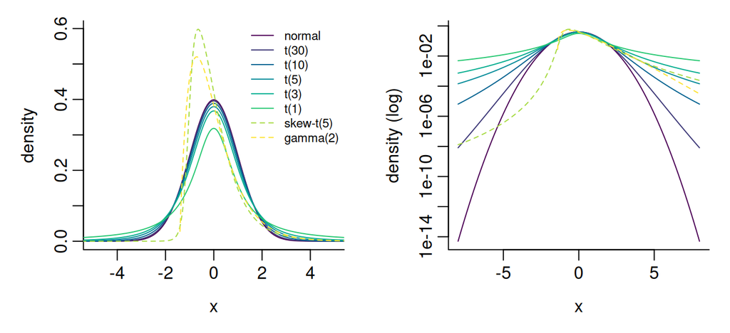

Density of the covariate, linear and log scale. Dashed: the skewed covariates.

## Moments of the covariate

A moment of order $k$ of $t_\nu$ is finite only for $k < \nu$. The elpd difference depends on $x_2$ and on $x_2^2$ (see below), so four moments matter. For $t_\nu$ they are:

| Quantity | Finite for | Value |
| --- | --- | --- |
| $\mathrm{E}[x_2]$ | $\nu > 1$ | 0 |
| $\mathrm{Var}[x_2] = \mathrm{E}[x_2^2]$ | $\nu > 2$ | $\nu / (\nu - 2)$ |
| Skewness of $x_2$ | $\nu > 3$ | 0 |
| $\mathrm{Var}[x_2^2]$ | $\nu > 4$ | $\dfrac{3\nu^2}{(\nu - 2)(\nu - 4)} - \left(\dfrac{\nu}{\nu - 2}\right)^2$ |

The skew-t and the gamma have mean 0 and variance 1. So $\mathrm{Var}[x_2^2] = \kappa - 1$, with the kurtosis $\kappa$. The gamma with shape $k$ has the skewness $2 / \sqrt{k}$ and $\kappa = 3 + 6 / k$. The skew-t moments come from the moments of the skew-normal and of $(w / \nu)^{-1/2}$.

| Covariate | E[x2] | Var[x2] | Skewness | Var[x2^2] |
| --- | --- | --- | --- | --- |
| normal | 0 | 1 | 0 | 2 |
| t(30) | 0 | 1.07 | 0 | 2.56 |
| t(10) | 0 | 1.25 | 0 | 4.69 |
| t(5) | 0 | 1.67 | 0 | 22.2 |
| t(3) | 0 | 3 | undefined | Inf |
| t(1) | undefined | Inf | undefined | Inf |
| skew-t(5) | 0 | 1 | 2.37 | 20.5 |
| gamma(2) | 0 | 1 | 1.41 | 5 |

Why $x_2^2$ matters: model A omits $\beta_t x_2$, so this term is part of its residual. The pointwise log predictive density of model A is then about

$$\log p_A(y_i) \approx -\tfrac{1}{2}\log(2\pi\hat\tau_A^2)
- \frac{(\beta_t x_{i2} + \varepsilon_i)^2}{2\hat\tau_A^2},$$

and the pointwise elpd difference contains $\beta_t^2 x_{i2}^2$ and $\beta_t x_{i2} \varepsilon_i$. The normal approximation sums these terms and uses $\widehat{\mathrm{SE}} = \sqrt{n}\,\mathrm{sd}(\text{pointwise})$. This relies on the central limit theorem, so it needs a finite variance of the pointwise terms, that is $\nu > 4$.

The expected pattern, for $\beta_t > 0$:

- **$\nu \ge 5$:** all three moments are finite. The covariate behaves like the normal one, only with more spread.
- **$\nu = 3$:** $\mathrm{Var}[x_2]$ is finite, but $\mathrm{Var}[x_2^2]$ is infinite. A few points with large $|x_2|$ dominate the sum. The sample SD underestimates the spread, so the SE is too small. The effect is moderate, because $\mathrm{E}[x_2^2]$ is still finite.
- **$\nu = 1$ (Cauchy):** $\mathrm{E}[x_2]$ is undefined and $\mathrm{E}[x_2^2]$ is infinite. Often one point dominates the sum. A larger $n$ does not help, because a larger sample has a more extreme maximum.
- **Skew-t and gamma:** the mean and the variance are as for the normal, and $\mathrm{Var}[x_2^2]$ is finite. So the central limit theorem holds. But $x_2$ has a long right tail, so $x_2^2$ and the pointwise terms are strongly skewed. For a small $n$ the sum is then still skewed, and the normal approximation can be poorly calibrated. A larger $n$ helps. The skew-t has the larger $\mathrm{Var}[x_2^2]$, so the effect is stronger for the skew-t than for the gamma.

For $\beta_t = 0$ model A misses nothing, so $x_2^2$ is not in the residual. But a point with a large $|x_2|$ has a leverage near 1 in model B, and its LOO term in model B is then extreme.

The outlier shift $\Delta \sqrt{\sigma^2 + \lVert\beta\rVert^2}$ does not depend on the covariate distribution. For a t covariate with a small $\nu$ the spread of $y$ is much larger than for the normal covariate, so the same shift is a weaker outlier.

These explanations are hypotheses. The pointwise terms per trial were not analysed.

## Outlier

As in the paper, the first observation gets the mean shift

$$\mu_1 = \Delta \sqrt{\sigma^2 + \lVert \beta \rVert^2},
\qquad \mu_i = 0 \text{ for } i > 1,$$

with $\Delta$ = `out_dev`. The scale $\sqrt{\sigma^2 + \lVert\beta\rVert^2}$ is the SD of $y$ for a normal covariate. It is kept for the other covariates, so the outlier has the same size in every cell. The skew-t and the gamma have variance 1, so for them the scale is again the SD of $y$.

## Test sets

The test sets come from the same DGP as the training sets, with the same covariate distribution. The target is the elpd difference on 4000 pooled test sets of size $n$.

# Simulation scenarios

| Factor | Levels |
| --- | --- |
| n | 32, 128, 512 |
| beta_t | 0, 0.2, 1 |
| out_dev | 0, 20 |
| x_dist | normal, t30, t10, t5, t3, t1, skewt5, gamma2 |

The figures for the normal covariate keep their names, `{fig}_gaussian_elpd.pdf`. The figures for the other covariates are `{fig}_gaussian_elpd_<x_dist>.pdf`. Each figure shows one covariate distribution.

# Results

Each section shows one paper figure. Each tab shows one covariate distribution: the normal, the t from many degrees of freedom to the Cauchy, then the skewed covariates. Inside each tab, the inner tabs show the unknown and the known noise variance.

## Calibration

PIT histograms of the normal approximation, as Fig. 6 of the paper (normal column). One column per $n$. For each $\beta_t$ one row without and one with the outlier. A calibrated SE gives a flat histogram inside the 99 % band.

### normal

#### unknown variance

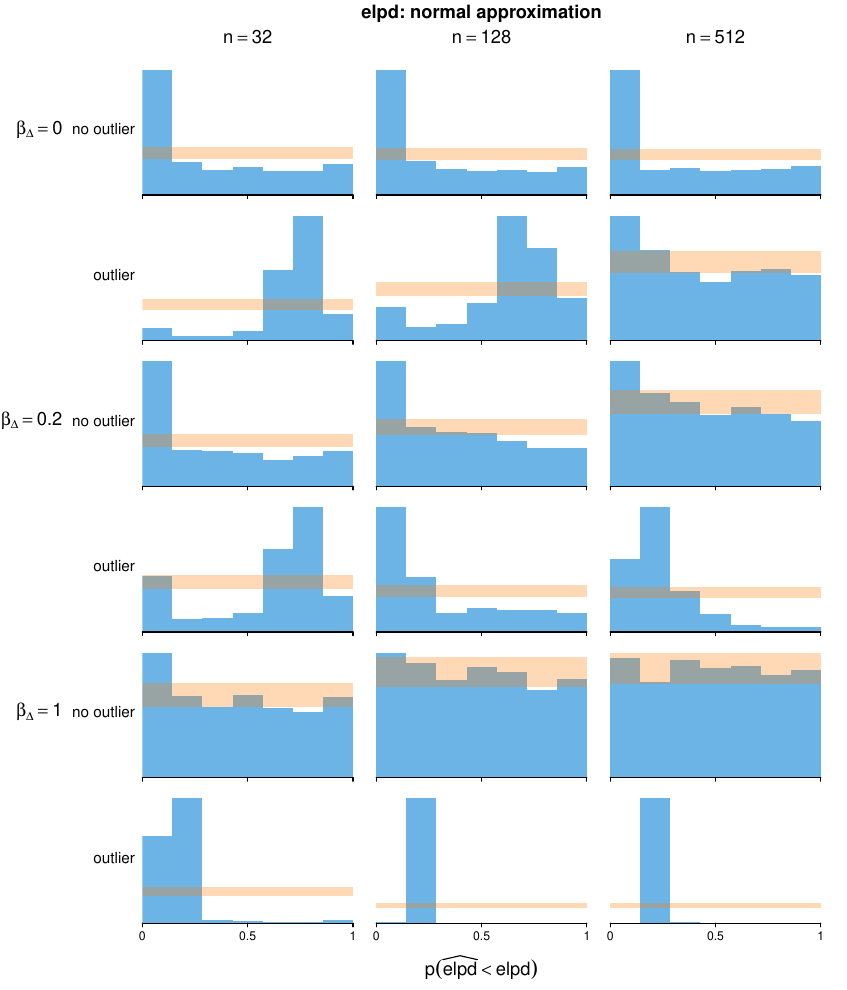

#### known variance (τ² = 1)

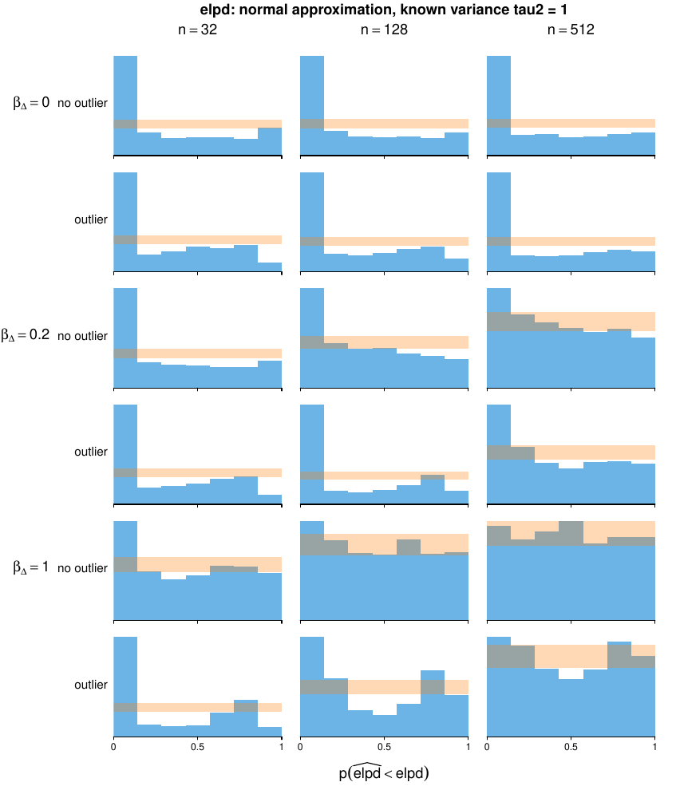

### t(30)

#### unknown variance

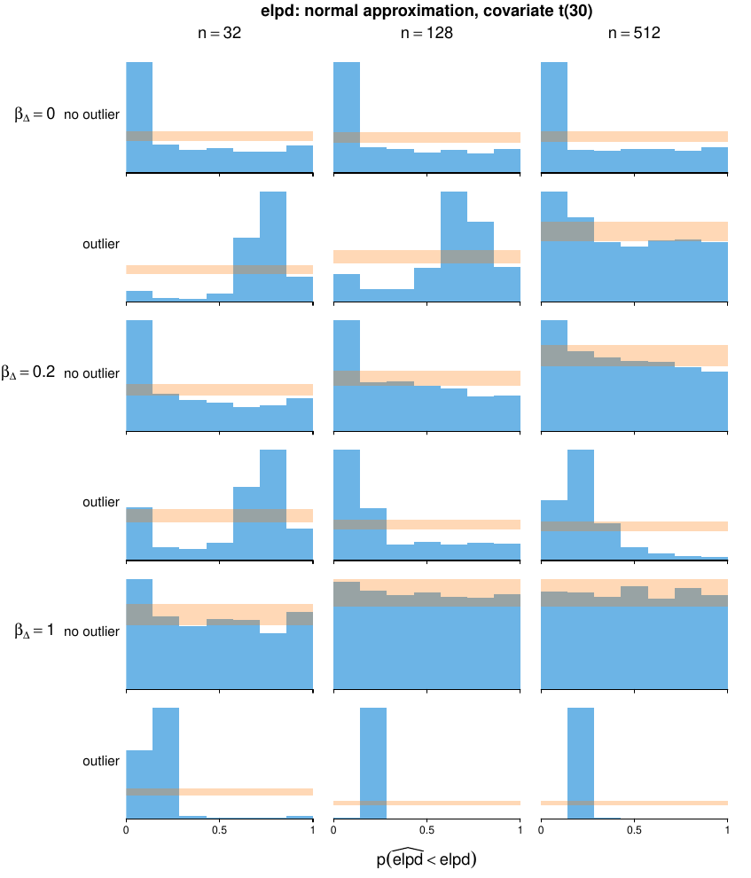

#### known variance (τ² = 1)

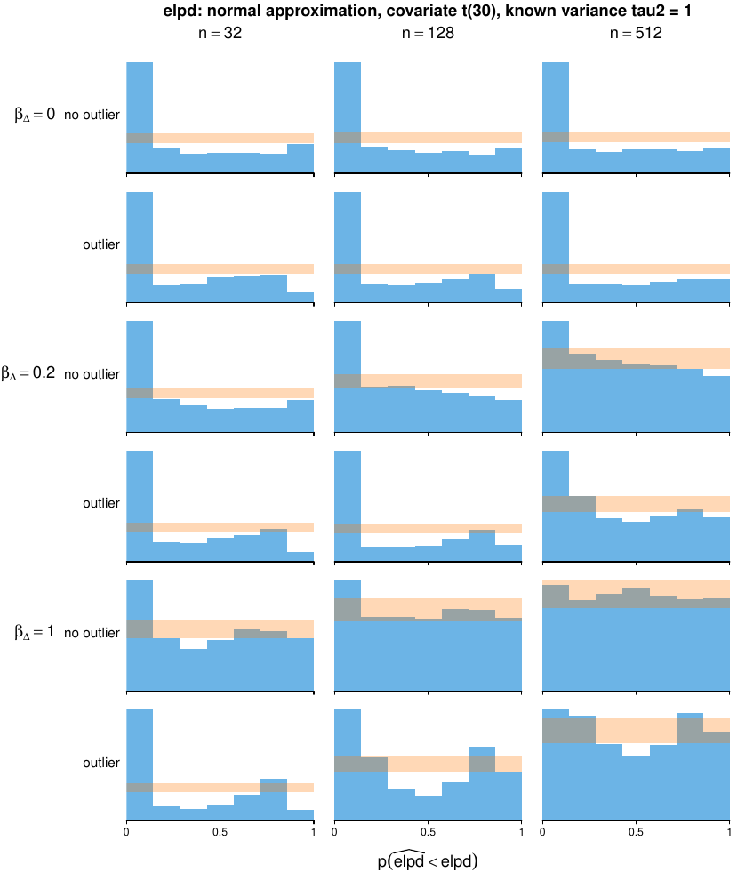

### t(10)

#### unknown variance

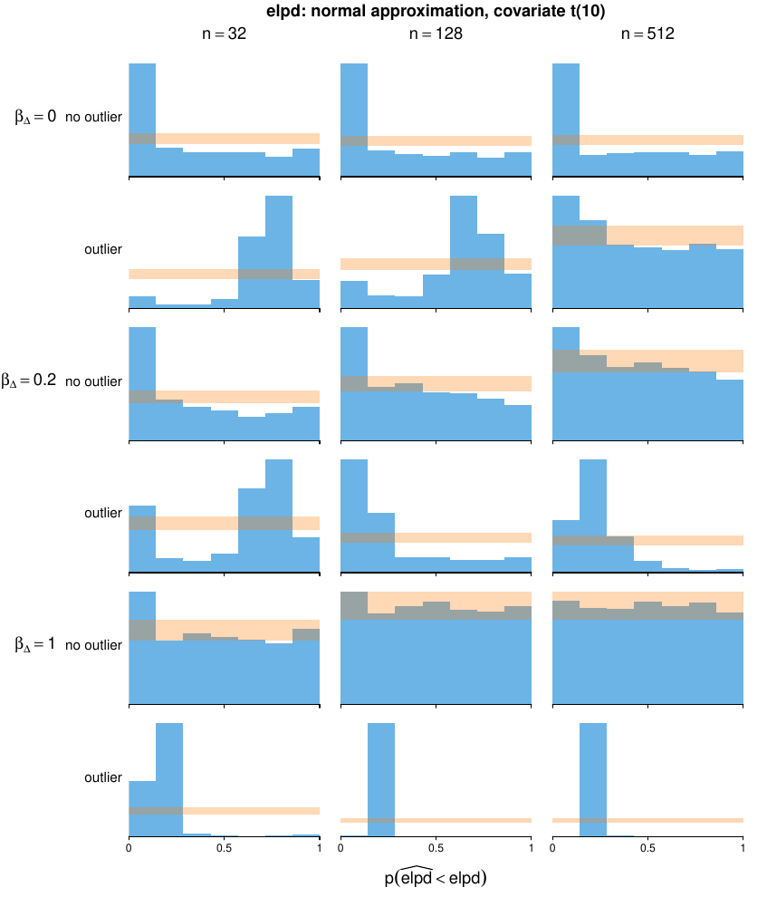

#### known variance (τ² = 1)

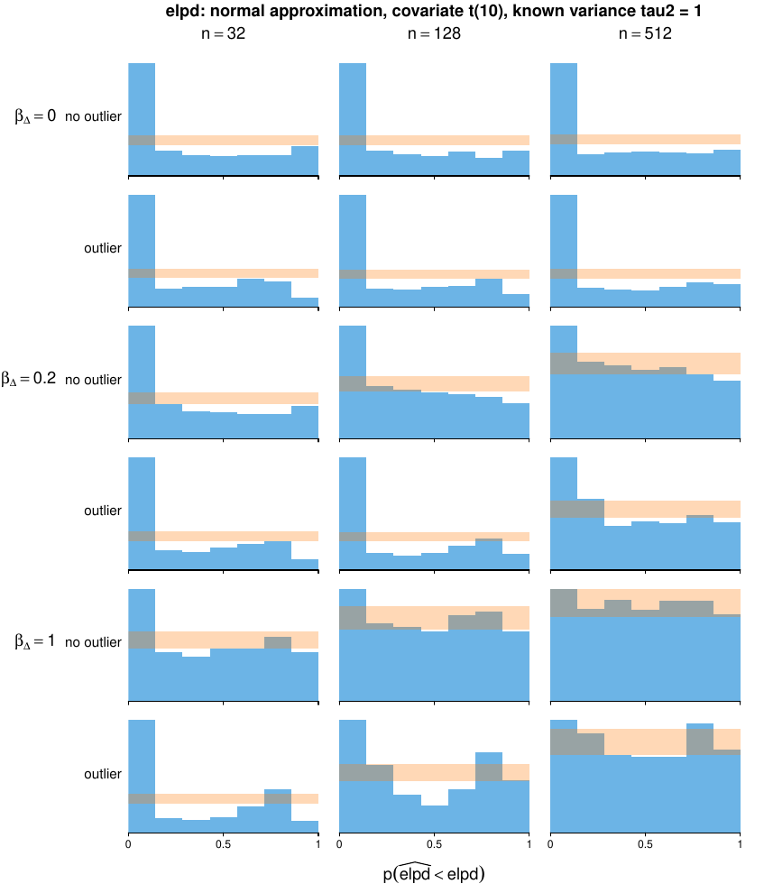

### t(5)

#### unknown variance

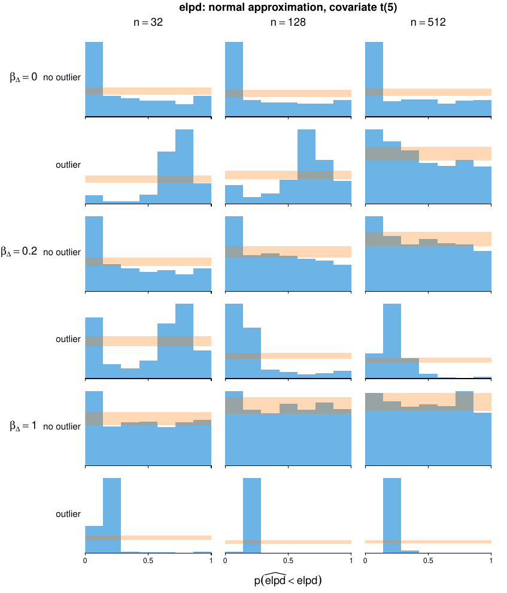

#### known variance (τ² = 1)

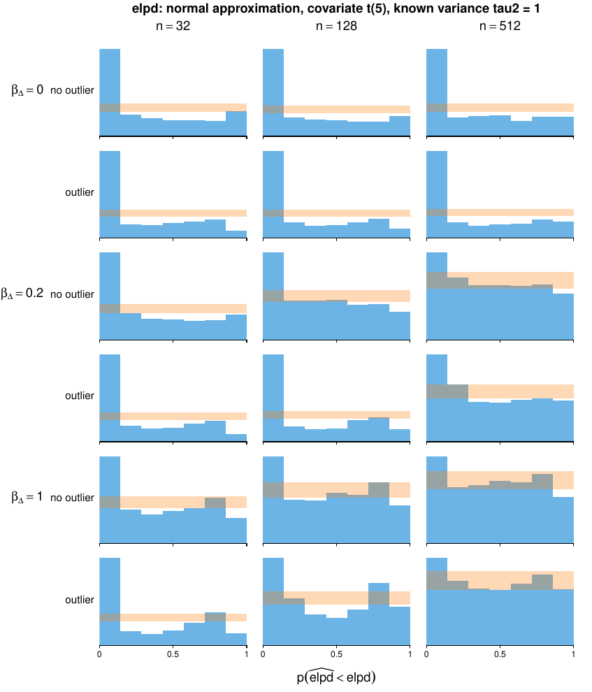

### t(3)

#### unknown variance

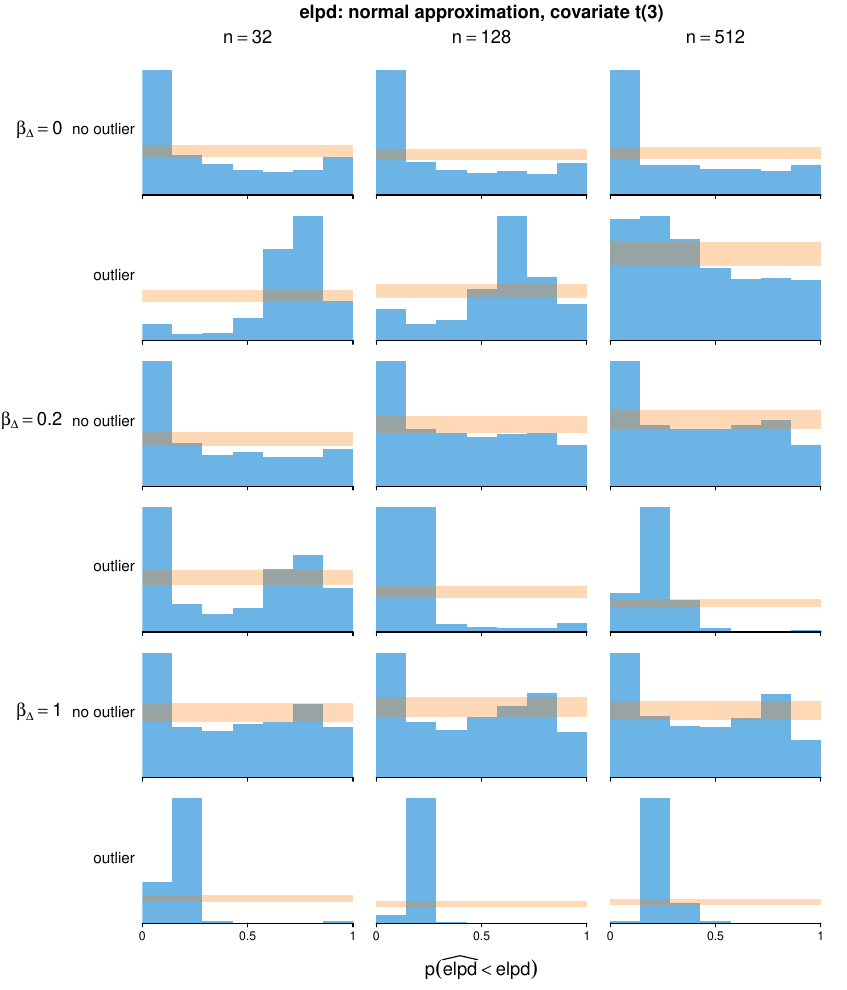

#### known variance (τ² = 1)

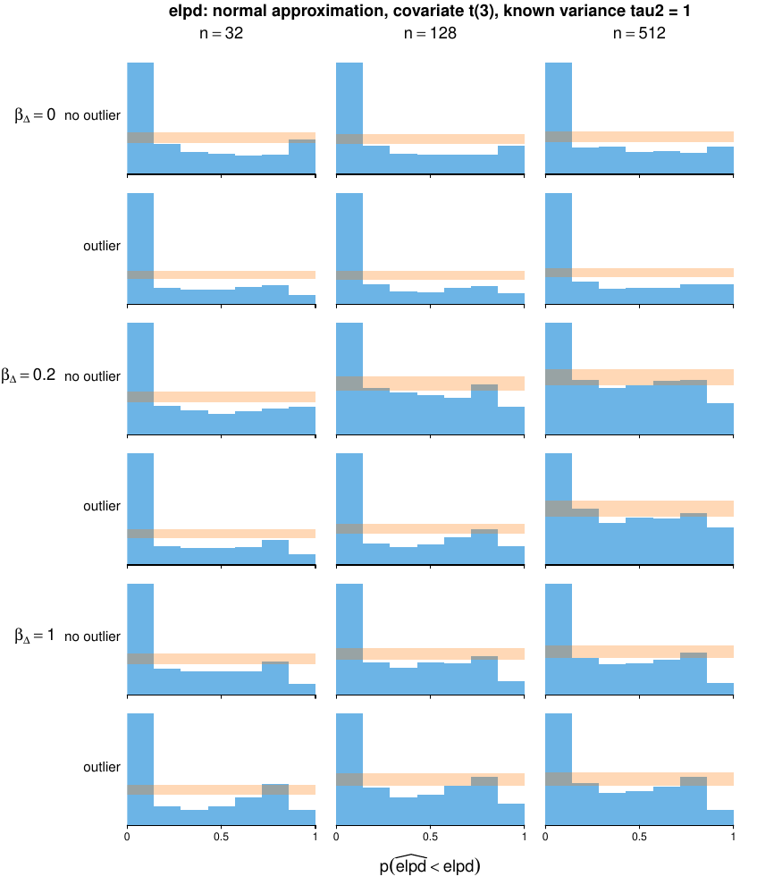

### t(1)

#### unknown variance

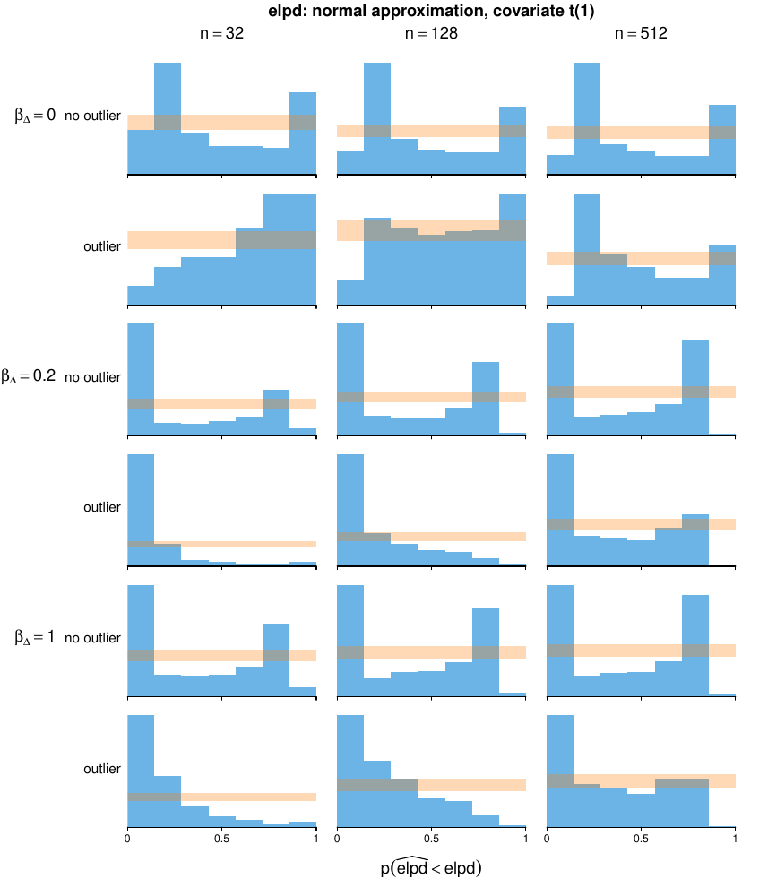

#### known variance (τ² = 1)

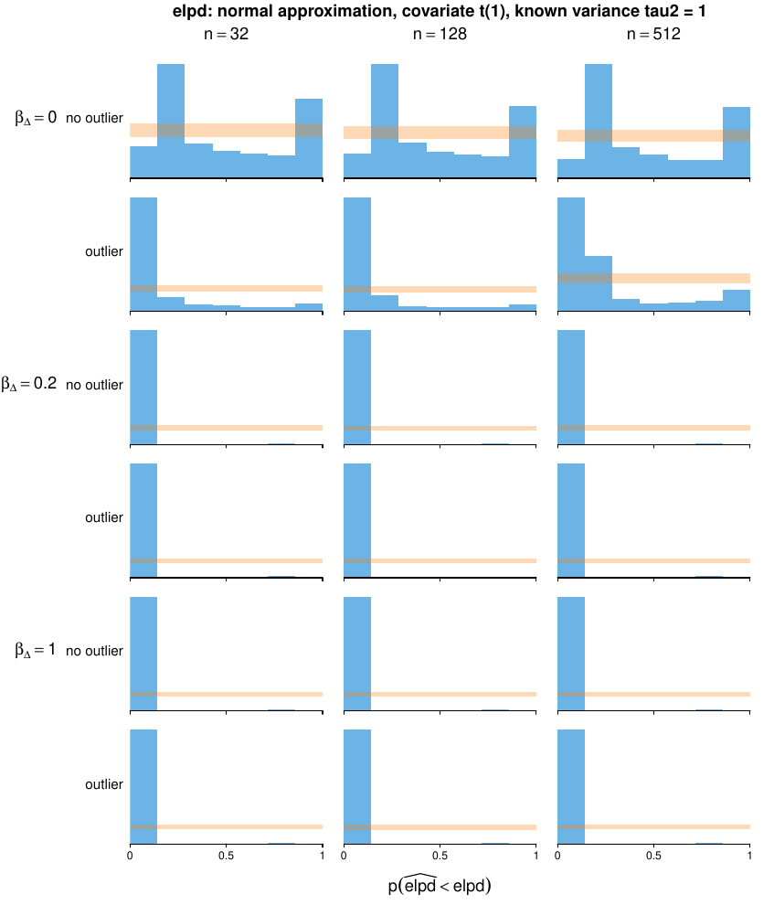

### skew-t(5)

#### unknown variance

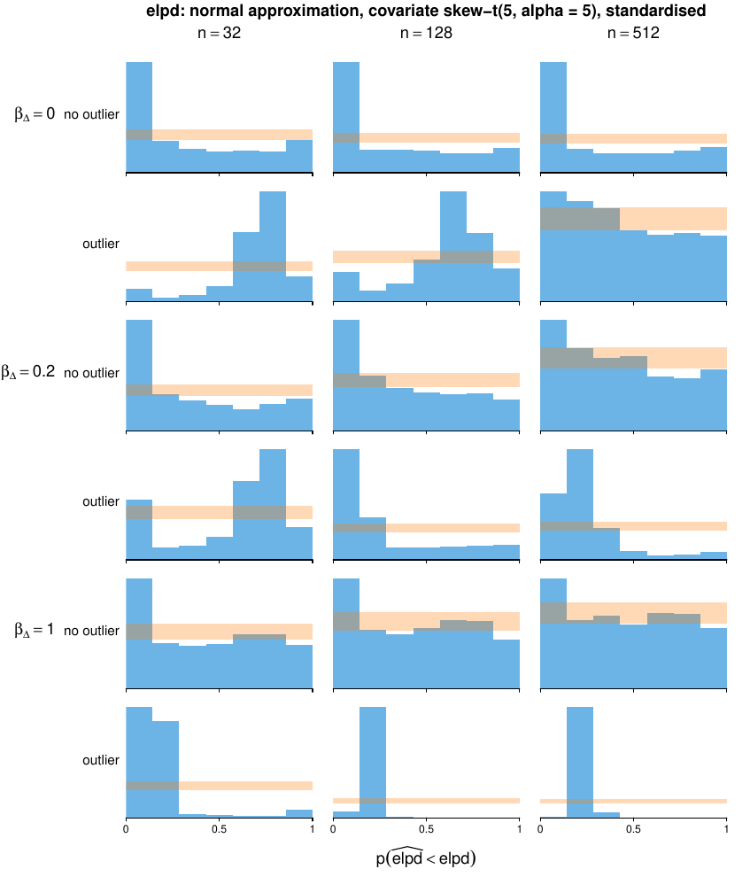

#### known variance (τ² = 1)

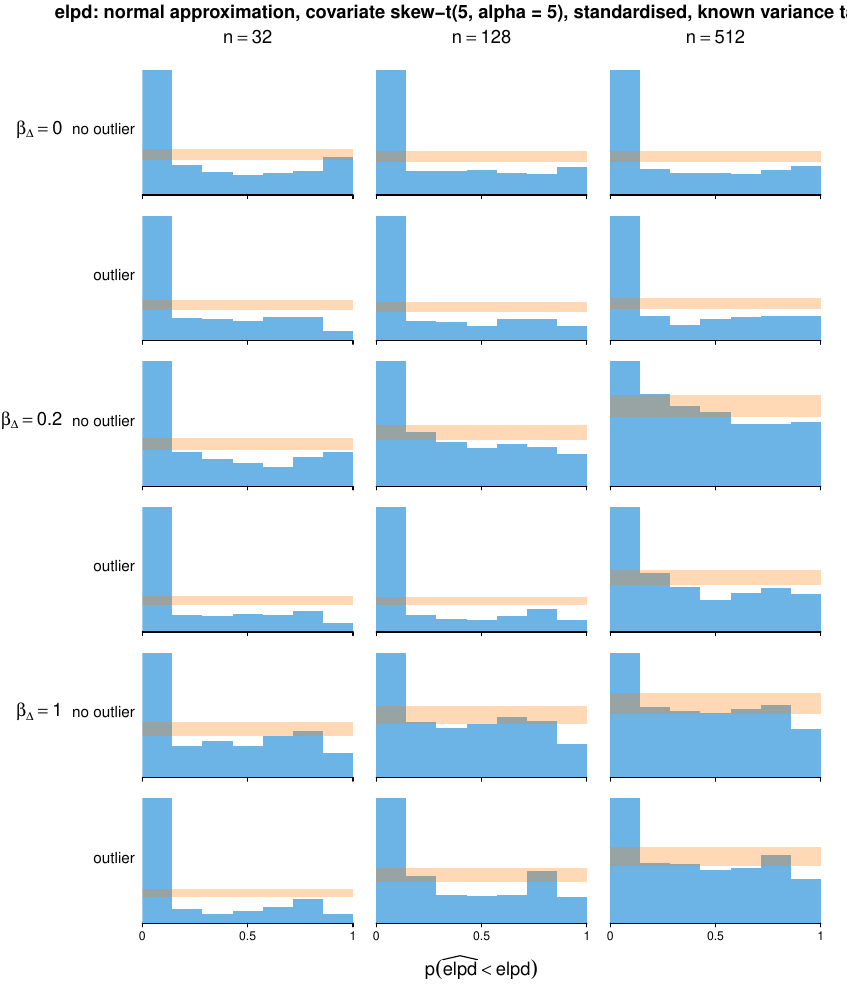

### gamma(2)

#### unknown variance

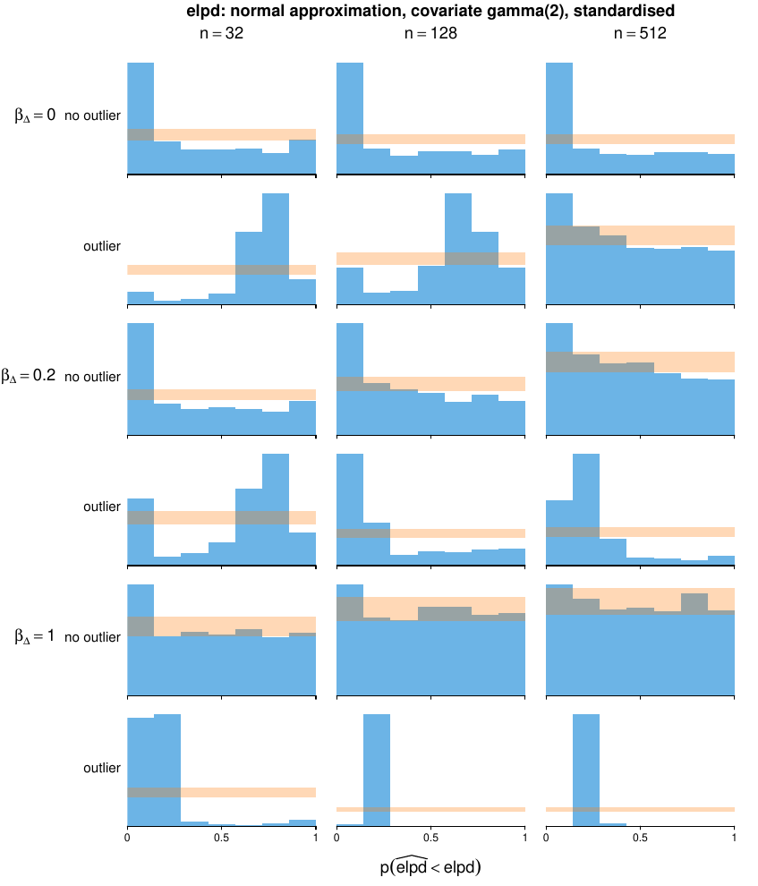

#### known variance (τ² = 1)

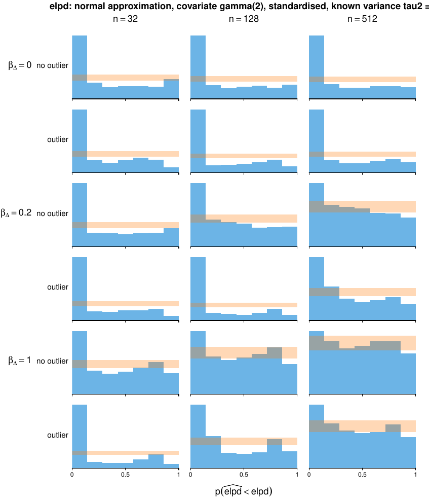

## Joint distribution

The LOO estimate against the target, without the outlier, as Fig. 5 of the paper. Points on the green diagonal are estimated without error.

### normal

#### unknown variance

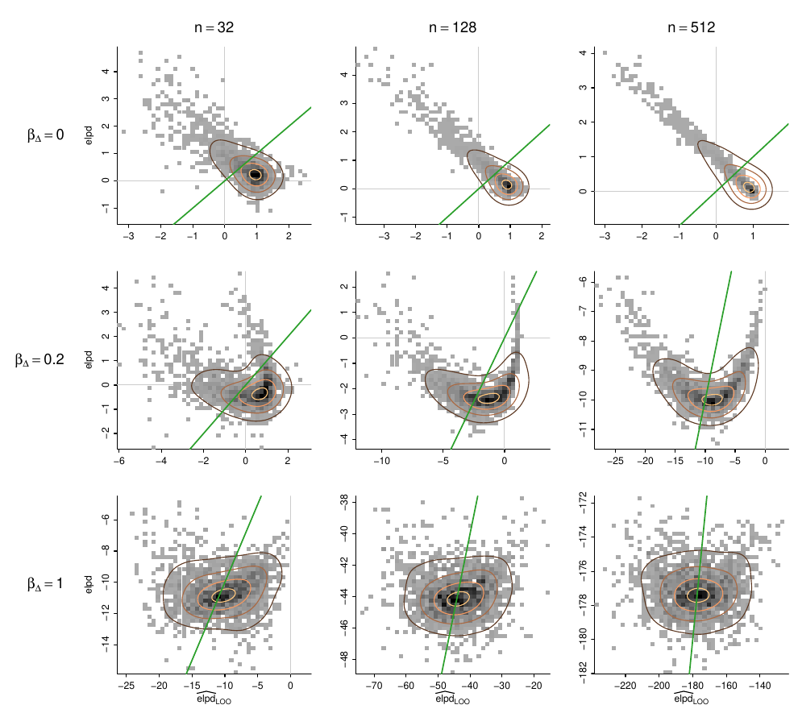

#### known variance (τ² = 1)

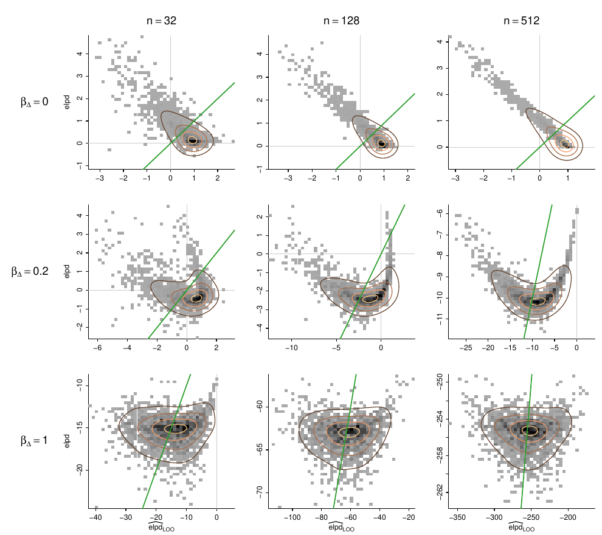

### t(30)

#### unknown variance

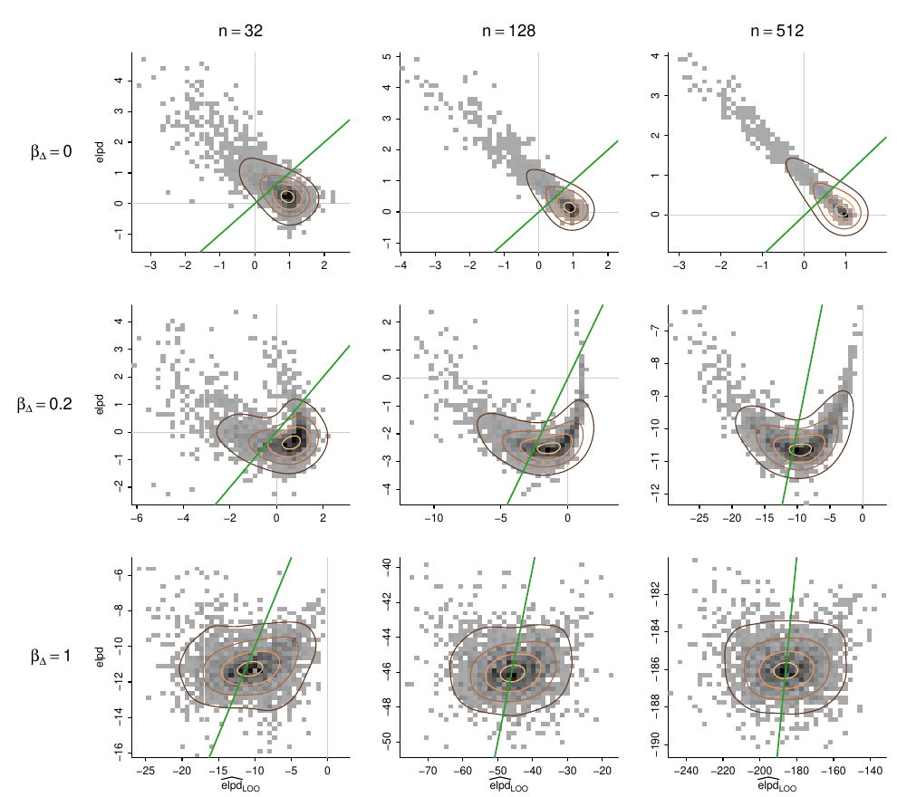

#### known variance (τ² = 1)

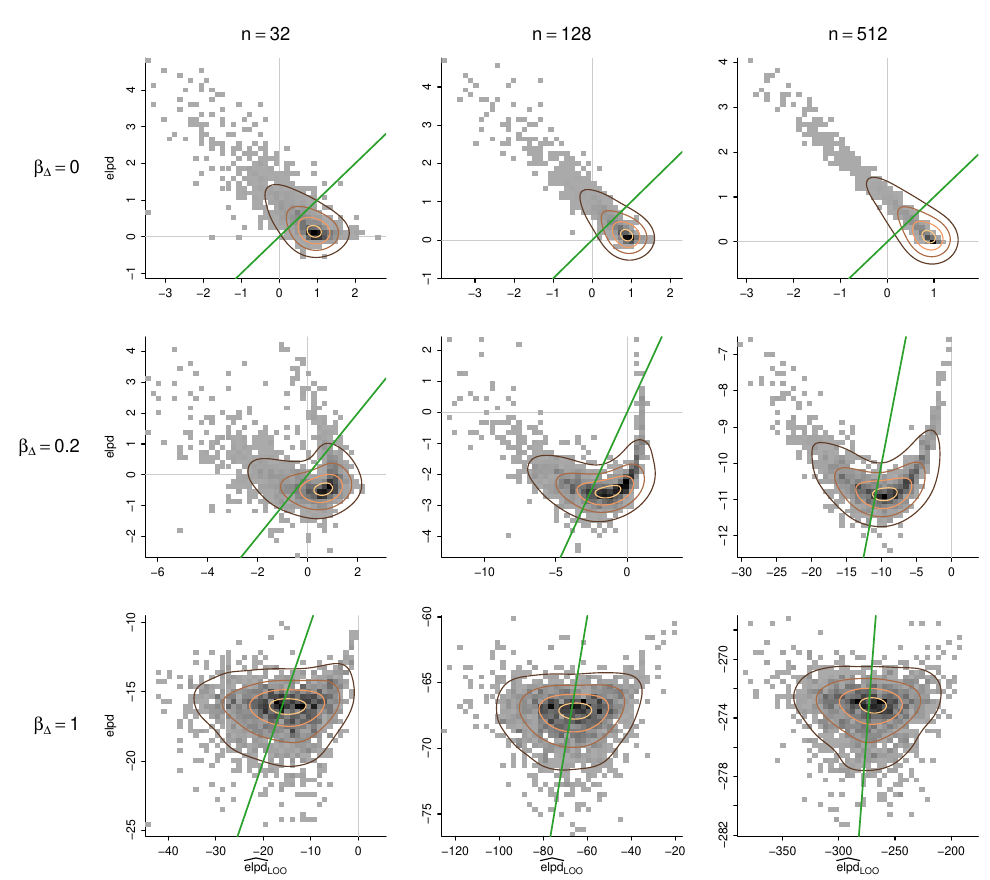

### t(10)

#### unknown variance

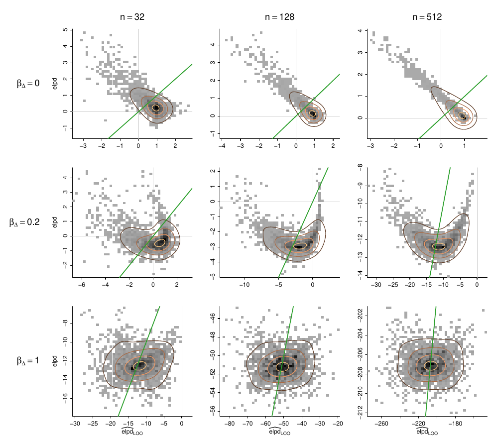

#### known variance (τ² = 1)

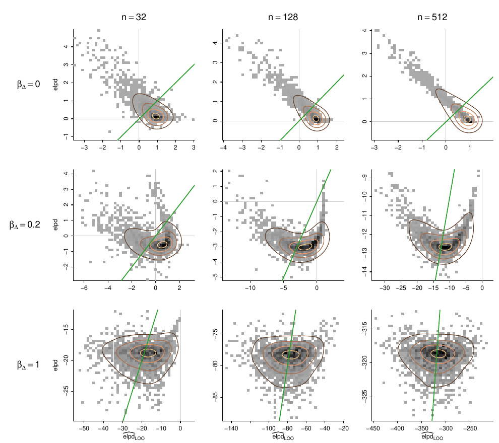

### t(5)

#### unknown variance

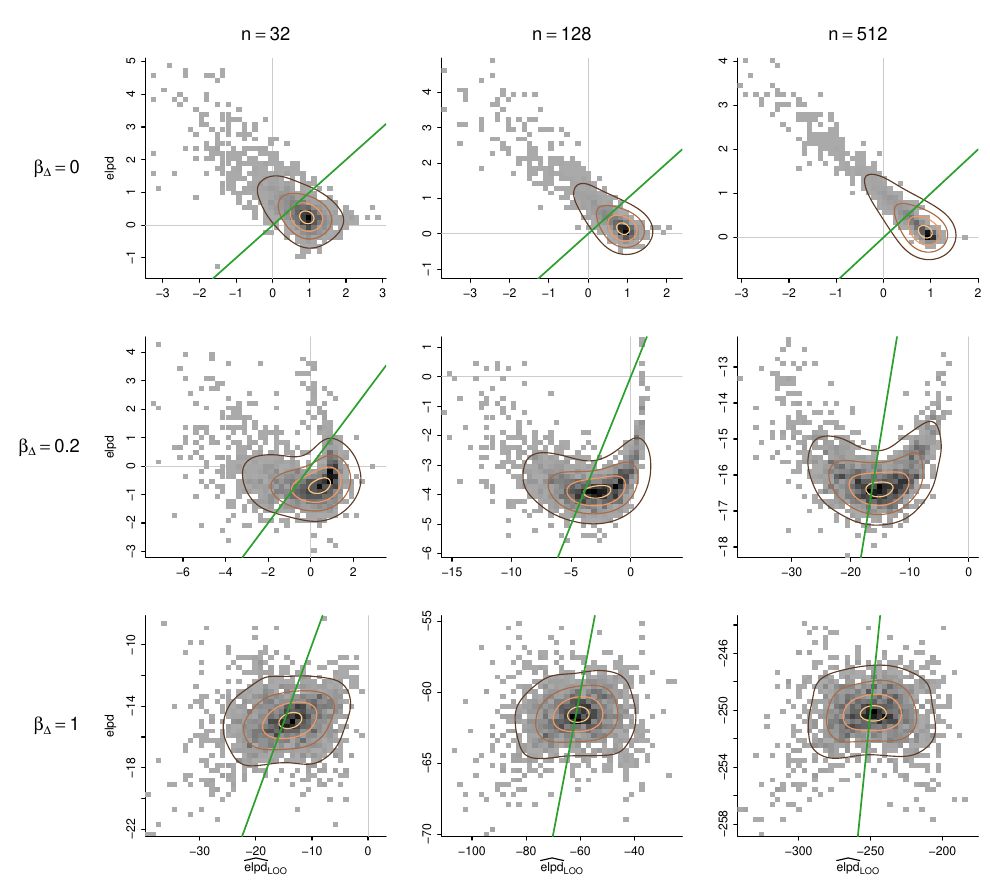

#### known variance (τ² = 1)

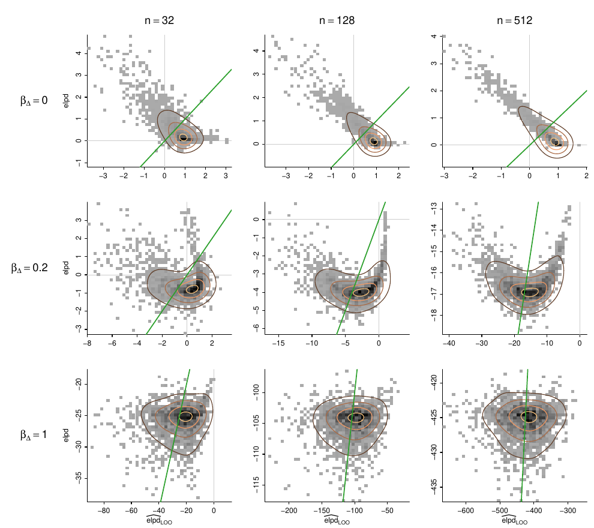

### t(3)

#### unknown variance

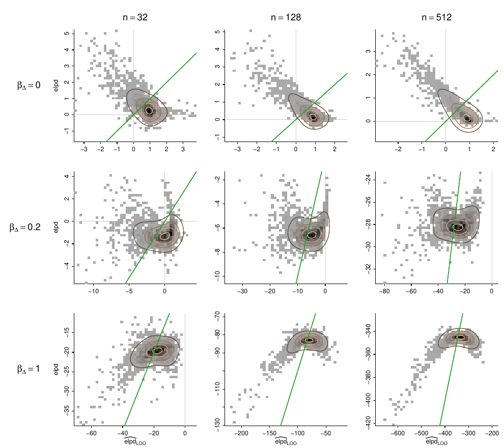

#### known variance (τ² = 1)

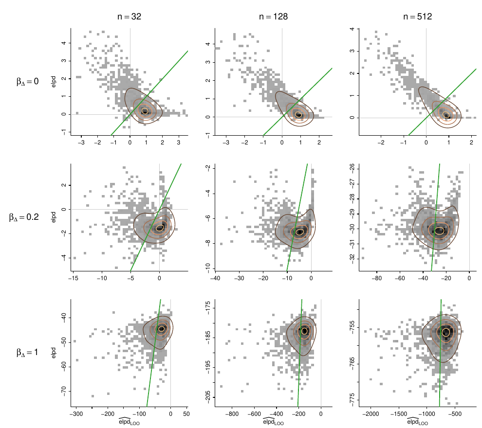

### t(1)

#### unknown variance

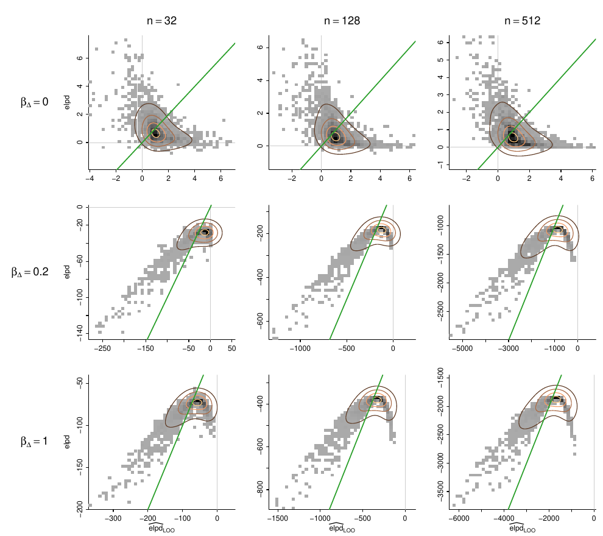

#### known variance (τ² = 1)

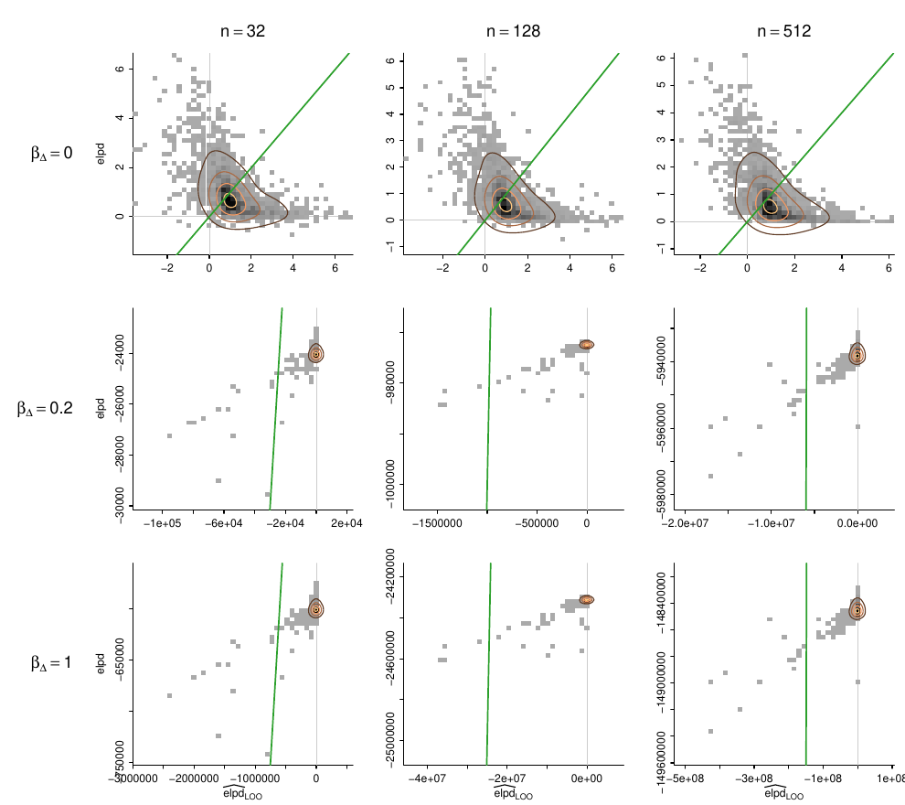

### skew-t(5)

#### unknown variance

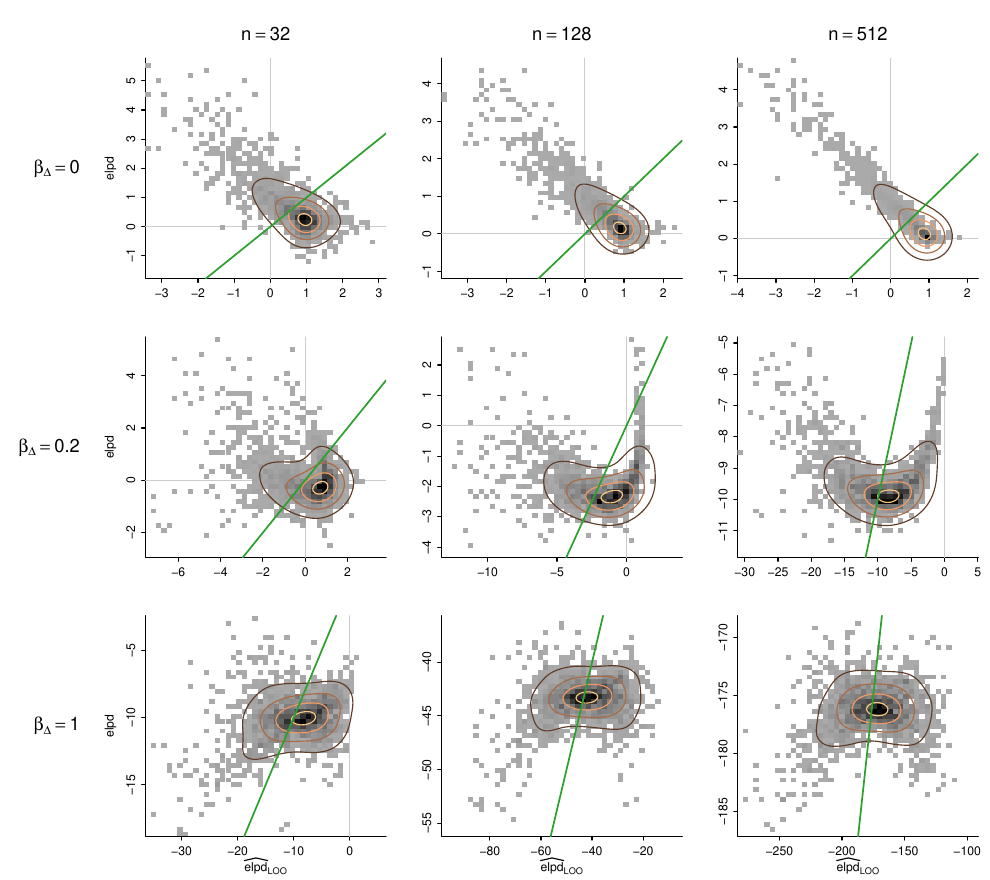

#### known variance (τ² = 1)

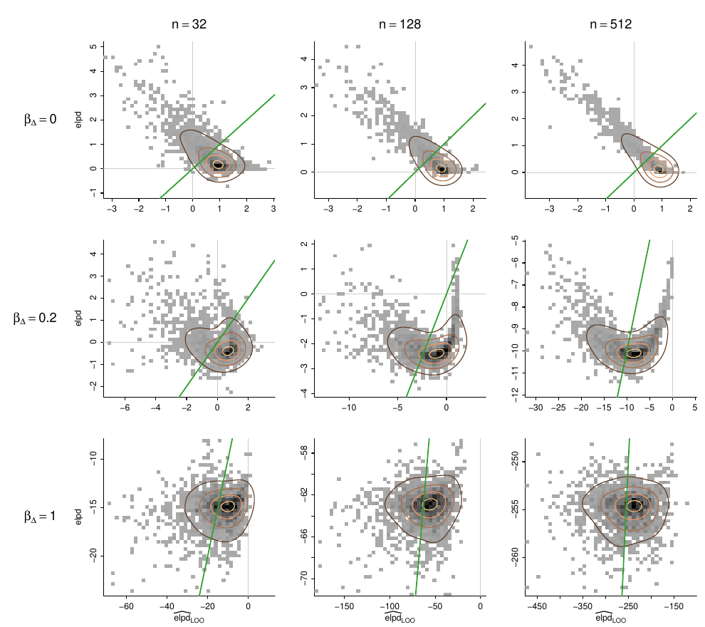